# Statistics for Psychologists 3.

**Computer lab 04**

**Course Number:** BTPS2040BA-E  
**Contact Information:** Please contact me through email anytime: abari.kalman@arts.unideb.hu

Author

Kálmán Abari

Published

March 9, 2025

**To earn 1 point**

To earn 1 point, submit all jamovi OMV files in this Computer lab that contain the activities you completed here. The subject of the email should be `Stat3 - Comp. lab 04`. Send the email to `abari.kurzus@gmail.com`.

# Worked Example 1

## Step 1. Import database

Open the `principal_subject_01.xlsx` file in jamovi.

Our database contains the grades of four subjects (mathematics, physics, computer science, chemistry).

[figure not shown]

## Step 2. Measure type

Set the measurement level of the variables. All variables are continuous, so we set the measurement level to `Continuous`.

[figure not shown]

## Step 3. Correlation matrix

Create a correlation matrix for the variables. Click on the `Analyses` tab, then select `Regression` and `Correlation Matrix`. Then, turn off the `Report significance` check box. So we get a correlation matrix without significance levels, we only need the correlation coefficients.

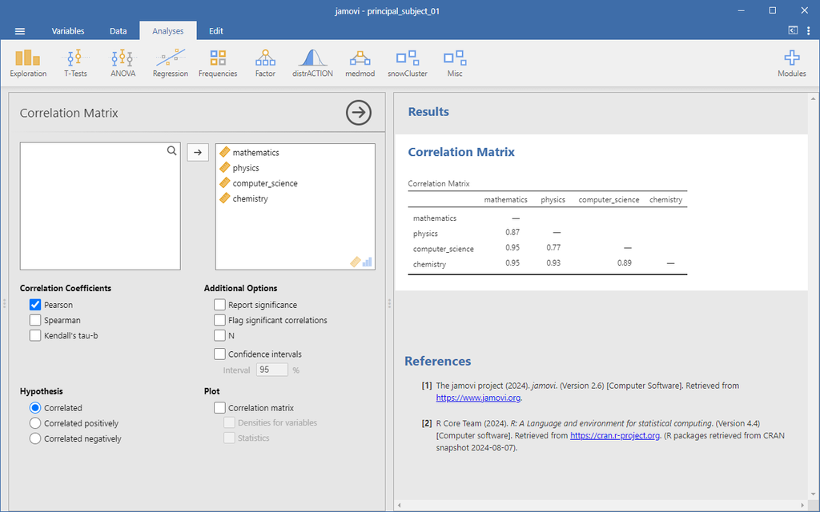

Based on the matrix, it seems that the grades move relatively together, that is, someone who has a better grade in mathematics also achieves good results in physics, computer science and chemistry. While someone who is weaker in one subject does not get very good grades in the other subjects either.

Based on these data, we can create an **aggregate indicator** that condenses the data of these subjects. Thus, it can be a measure of **the susceptibility to real subjects**.

## Step 4. PCA in jamovi

How to perform PCA in Jamovi: Step-by-Step Guide:

1. Click on **Analyses > Factor > Principal Component Analysis (PCA)**
2. Move the variables (e.g., **mathematics, physics, computer_science, chemistry**) into the **Variables** box.

This image shows the results of a **Principal Component Analysis (PCA)** in Jamovi, focusing on four variables: **mathematics, physics, computer_science, and chemistry**.

As you see **Number of Components:** **Based on parallel analysis** is selected.

- This method helps to determine the appropriate number of components to retain by comparing the actual eigenvalues to those generated from random data of the same size.

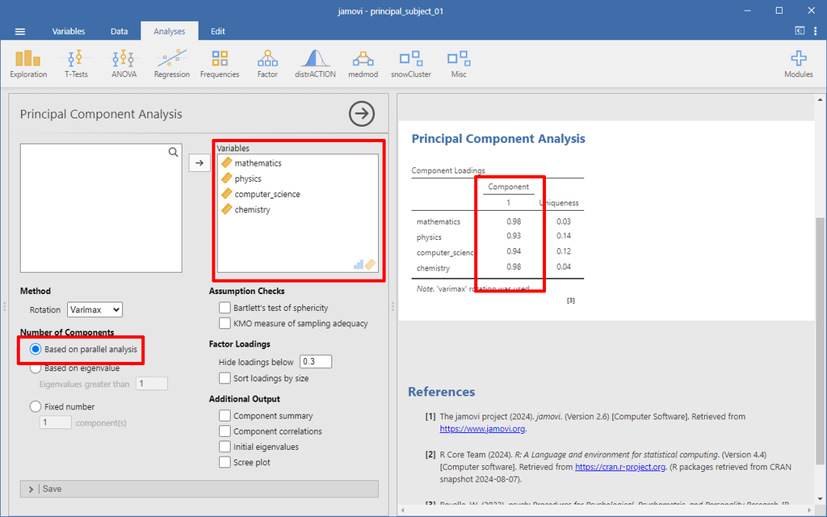

#### **Structure of the “Component Loadings” table:**

- On the right side, in the **“Component Loadings”** table, we can see **only one component** listed.
- If more components were relevant, they would appear as separate columns.
- Since there is **only one column** for components, it suggests that retaining **one principal component** is optimal.
- **Component Loadings:** The table shows the **component loadings** for a single extracted component:
  - **mathematics:** 0.98
  - **physics:** 0.93
  - **computer_science:** 0.94
  - **chemistry:** 0.98
  - The high loadings suggest that these variables are strongly associated with the single extracted component.
- **Uniqueness:** Low uniqueness values indicate that most of the variance in these variables is explained by the extracted component:
  - **mathematics:** 0.03
  - **physics:** 0.14
  - **computer_science:** 0.12
  - **chemistry:** 0.04
  - Low uniqueness values imply that a significant portion of the variance is captured by this component.

## Step 5. Saving the Principal Component in Jamovi

### **How was the component saved?**

- In the **Principal Component Analysis** settings (on the right side), the option **“Save > Component scores”** is checked.
- This setting tells Jamovi to create a new column in the dataset containing the scores for the extracted component.
- As a result, a new column named **“Score Component 1”** appears in the dataset (highlighted on the left side).

[figure not shown]

In this image, we can see that the result of the Principal Component Analysis (PCA) has been saved into the dataset as a new column called **“Score Component 1”**. Why this step is useful?

### **What are these component scores?**

- The new column (**“Score Component 1”**) contains the **component scores** for each case (or participant) in the dataset.
- **Component scores** represent a linear combination of the original variables (**mathematics, physics, computer_science, chemistry**) weighted by the loadings of the extracted component.
- Essentially, these scores summarize the information from the original variables into a **single score** for each case, capturing the main pattern of variation.

### Why save the component scores? Benefits:

#### **A. Data Reduction:**

- Instead of working with multiple variables (**mathematics, physics, etc.**), we can now work with a single summarized score (**Score Component 1**).
- Simplifies analysis by reducing the number of variables without losing significant information.

#### **B. Multicollinearity Reduction:**

- Since the original variables might be highly correlated, working with a single component score **eliminates multicollinearity**.
- This is particularly useful in regression analyses.

#### **C. New Variable for Further Analysis:**

- The new component score can be used in subsequent analyses, such as:
  - **Regression:** To predict outcomes using the component score instead of the original variables.
  - **Clustering:** To group cases based on their component scores.
  - **ANOVA:** To test differences in component scores across groups.

### **How to Interpret the Value of “Score Component 1” in PCA**

##### **1. What is “Score Component 1”?**

- **“Score Component 1”** represents the **component scores** for each observation (or case) in the dataset based on the first principal component extracted during PCA.
- These scores are **linear combinations** of the original variables (e.g., mathematics, physics, computer_science, chemistry), weighted by the **component loadings**.
- The purpose of these scores is to **summarize** the information from the original variables into a **single composite score** that reflects the main pattern of variation.

##### **2. How to Interpret the Values:**

- If the first component represents **academic performance** based on high loadings for mathematics, physics, computer_science, and chemistry:
  - **Positive scores:** Suggest high academic performance across these subjects.
  - **Negative scores:** Suggest lower academic performance.
- In practice, you could use these scores as a **new variable** for further analyses (e.g., regression or clustering).

## Step 6. Number of components

### **How to Determine the Number of Principal Components in Jamovi**

In Jamovi, you can determine the number of principal components to retain using three main methods:

- **Parallel Analysis**
- **Eigenvalue > 1 Criterion, and**
- **Fixed Number**.

Each method has its own purpose and is useful in different situations. Let’s explore each of them in detail.

### **1. Parallel Analysis:**

**Where to find it:**

- In the PCA settings, under **“Number of Components”**, select **“Based on parallel analysis”**.

**What it does:**

- Parallel Analysis compares the **actual eigenvalues** of the components to **randomly generated eigenvalues** from data of the same size.
- A component is retained if its eigenvalue is **greater than the eigenvalues from random data**.
- This method prevents **overestimating** the number of components.

**When to use it:**

- Recommended when you want a **more accurate and conservative** estimate of the number of components.
- Useful in large datasets where the **eigenvalue > 1** rule tends to retain too many components.

**Strengths:**

- More reliable than the eigenvalue > 1 rule, especially for large datasets.
- Helps to avoid keeping too many irrelevant components.

### **2. Eigenvalue > 1 Criterion (Kaiser’s Criterion):**

**Where to find it:**

- In the PCA settings, choose **“Based on eigenvalue”** and specify the threshold as **greater than 1**.

**What it does:**

- Retains components with **eigenvalues greater than 1**.
- The idea is that a component with an eigenvalue > 1 explains more variance than a single original variable.

**When to use it:**

- Appropriate for **exploratory analysis** when you need a **quick and simple** method.
- Commonly used in **social sciences** and when the dataset is **not too large**.

**Strengths:**

- Easy to use and interpret.
- Effective for small to medium-sized datasets.

**Limitations:**

- Can **overestimate** the number of components in large datasets.
- Less reliable compared to **parallel analysis**.

### **3. Fixed Number of Components:**

**Where to find it:**

- In the PCA settings, select **“Fixed number”** and manually specify the number of components.

**What it does:**

- Retains a **pre-determined** number of components based on theoretical or practical considerations.
- Useful when you have a **prior hypothesis** about how many components to expect.

**When to use it:**

- When you have **theoretical justification** for a specific number of components.
- In **confirmatory PCA** to test if a specific structure fits the data.

**Strengths:**

- Useful for testing **theoretical models**.
- Allows for focused analysis when the expected number of components is known.

**Limitations:**

- Risk of **subjectivity** if not justified properly.
- May **miss relevant components** if the number is underestimated.

### **Summary: Which Method to Use and When?**

| **Method** | **When to Use** | **Strengths** |
| --- | --- | --- |
| **Parallel Analysis** | For accurate and conservative estimates, especially in **large datasets**. | Most reliable, prevents overestimation. |
| **Eigenvalue > 1 Criterion** | For quick, exploratory analysis in **small to medium datasets**. | Simple and effective. |
| **Fixed Number of Components** | When you have a **theoretical basis** for the number of components. | Useful for confirmatory analysis. |

**In Practice:**

- Use **Parallel Analysis** for the most reliable results.
- Use **Eigenvalue > 1** for quick, initial insights.
- Use **Fixed Number** if you have a strong theoretical reason.

In Jamovi, selecting the right method ensures that you retain the **appropriate number of components** for meaningful analysis!

Next image shows a **Principal Component Analysis (PCA)** in Jamovi where the number of components is **manually set to 2** using the **“Fixed number”** option. This setting forces Jamovi to extract **exactly two components** regardless of their eigenvalues or other criteria.

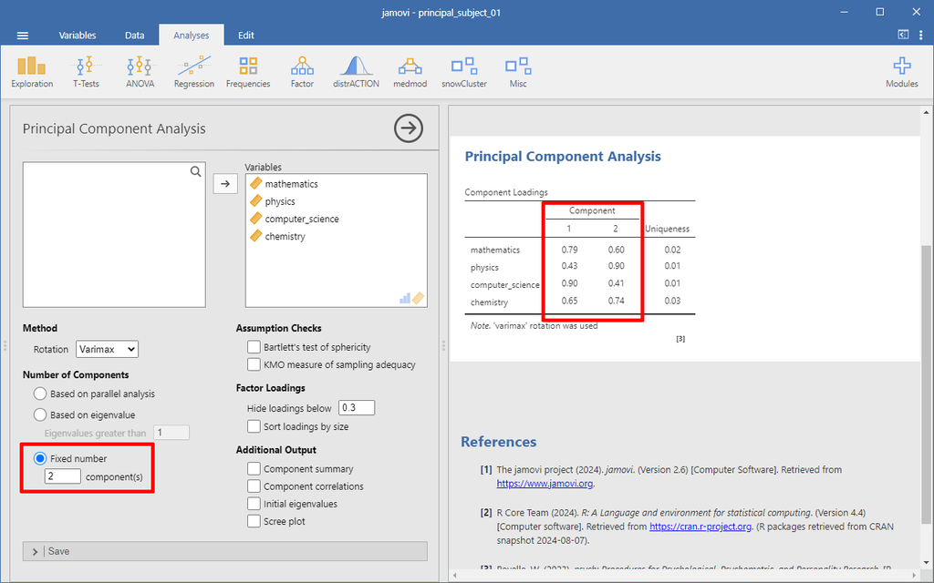

[figure not shown]

You might use a fixed number of components if you have a **theoretical reason** or a hypothesis suggesting that exactly two components are meaningful.

The **Component Loadings** table shows how strongly each variable correlates with each of the two extracted components.

- Loadings range from **-1 to 1**: - Values **above 0.70** → **Strong** relationship.
- Values between **0.30 and 0.70** → **Moderate** relationship.
- Values **below 0.30** → **Weak** relationship.

### **a. Interpretation of Component 1:**

- **High loadings:**
  - **computer_science (0.90)** and **mathematics (0.79)** have strong positive relationships with Component 1.
  - Suggests that **Component 1** might represent a factor related to **analytical or quantitative skills**.

### **b. Interpretation of Component 2:**

- **High loadings:**
  - **physics (0.90)** and **chemistry (0.74)** show strong positive relationships with Component 2.
  - Suggests that **Component 2** might represent a factor related to **natural sciences or experimental skills**.

### **c. Cross-Loadings:**

- **mathematics (0.60 on Component 2)** and **chemistry (0.65 on Component 1)** have moderate cross-loadings.
- Cross-loadings can indicate that some variables are **associated with multiple components**.
- This suggests that the distinction between the two components might not be very clear-cut.

### **Uniqueness Values: What Do They Mean?**

- **Uniqueness** represents the proportion of variance in each variable **not explained** by the components.
- Low uniqueness (close to **0.00**) suggests that most of the variance is **well explained** by the components.

**In this case:** - **Uniqueness** values range from **0.01 to 0.03**, indicating that the two components together **explain almost all the variance** in each variable.  
- This is a sign that the two-component solution is **effective and appropriate**.

### **Summary: Key Insights**

1. **Number of Components:** Fixed at **2**, likely based on a theoretical reason.
2. **Component 1:** Strongly associated with **mathematics and computer science** → Suggests an **analytical skills** factor.
3. **Component 2:** Strongly associated with **physics and chemistry** → Suggests a **natural sciences** factor.
4. **Low Uniqueness:** Indicates that the two components explain **almost all the variance**.
5. **Cross-Loadings:** Some variables relate to both components, suggesting a **partial overlap** between the factors.

**Conclusion:** The analysis suggests a **two-factor structure**:

- **Component 1:** Analytical skills (mathematics, computer science).
- **Component 2:** Natural sciences skills (physics, chemistry).
- The low uniqueness and high loadings support this structure, making it a **meaningful and effective solution**.

We can try the PCA with 3 components.

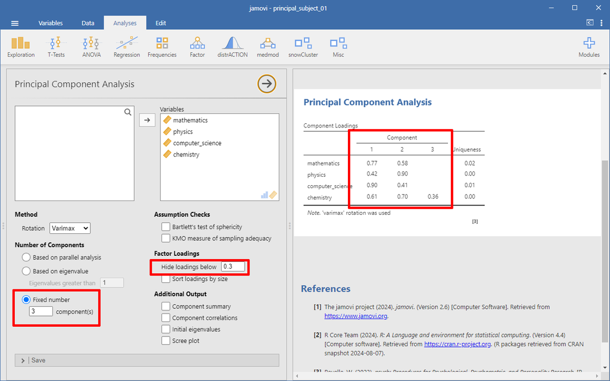

### **a. Interpretation of Component 1:**

- **Strong Loadings:**
  - **computer_science (0.90)** and **mathematics (0.77)** → Suggests that Component 1 might represent a factor related to **analytical or computational skills**.
- **Moderate Loadings:**
  - **chemistry (0.61)** → Suggests a partial relationship with Component 1.

### **b. Interpretation of Component 2:**

- **Strong Loadings:**
  - **physics (0.90)** → Suggests Component 2 might represent a factor related to **natural sciences or physical sciences skills**.
- **Moderate Loadings:**
  - **mathematics (0.58)** and **computer_science (0.41)** → Indicate a partial overlap with Component 2.

### **c. Interpretation of Component 3:**

- **Moderate Loading:**
  - **chemistry (0.36)** → Suggests that Component 3 might capture some **unique aspect** of chemistry not explained by the other two components.
- **Other variables:** No significant loadings, suggesting that Component 3 may capture a **narrower or more specific aspect** of the data.

### **Uniqueness Values: What Do They Mean?**

- **Uniqueness** represents the proportion of variance in each variable **not explained** by the components.
- **Low uniqueness (close to 0.00):** Suggests that the three components together **explain almost all the variance** in each variable.

**In this case:** - All uniqueness values are **close to 0.00**, indicating that the three-component solution is **effective and appropriate**.

### **Key Observations:**

- **Component 1:** Focuses on **analytical and computational skills** (mathematics, computer_science).
- **Component 2:** Focuses on **natural sciences skills** (physics, partially mathematics).
- **Component 3:** Captures a **specific aspect of chemistry**.
- **Low Uniqueness:** Suggests that these three components together **explain nearly all the variance**.

### **Summary: Key Insights from the Image**

1. **Fixed Components:** Analysis was forced to extract **3 components**.
2. **Varimax Rotation:** Simplified interpretation by making variables load strongly on one component.
3. **Strong Loadings:** Suggest a clear structure with analytical, natural sciences, and a specific chemistry factor.
4. **Low Uniqueness:** Confirms that the three-component model is **effective**.

Finally, the 4 component PCA:

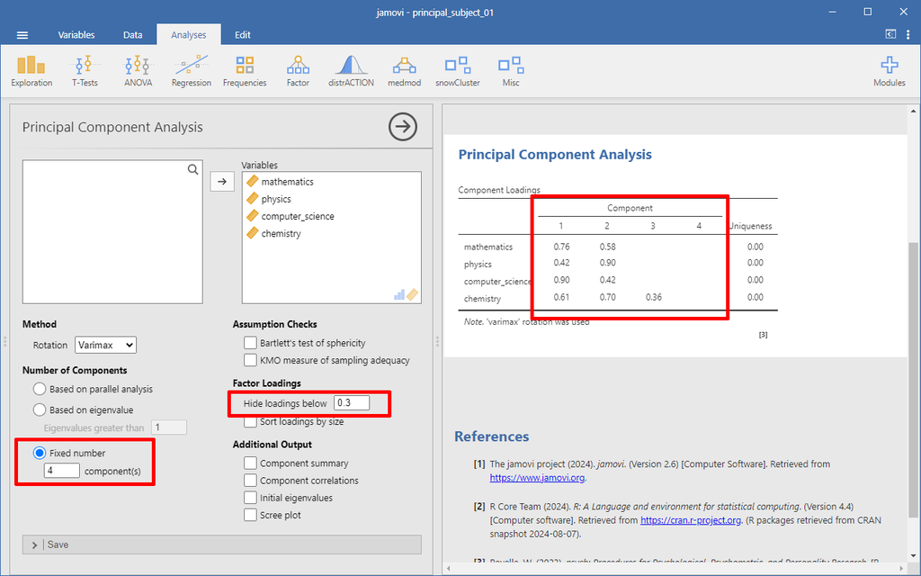

### **a. Interpretation of Component 1:**

- **Strong Loadings:**
  - **computer_science (0.90)** and **mathematics (0.76)** → Suggests that Component 1 might represent a factor related to **analytical or computational skills**.
- **Moderate Loadings:**
  - **chemistry (0.61)** → Suggests a partial relationship with Component 1.

### **b. Interpretation of Component 2:**

- **Strong Loadings:**
  - **physics (0.90)** → Suggests Component 2 might represent a factor related to **natural sciences or physical sciences skills**.
- **Moderate Loadings:**
  - **mathematics (0.58)** and **computer_science (0.42)** → Indicate a partial overlap with Component 2.

### **c. Interpretation of Component 3:**

- **Moderate Loading:**
  - **chemistry (0.36)** → Suggests that Component 3 might capture some **unique aspect** of chemistry not explained by the other two components.
- **Other variables:** No significant loadings, suggesting that Component 3 may capture a **narrower or more specific aspect** of the data.

### **d. Interpretation of Component 4:**

- **No Loadings:**
  - No variables have substantial loadings on **Component 4**.
- **Interpretation:**
  - Suggests that Component 4 may **not capture any meaningful variance** or that the decision to extract four components may not be justified.
  - Likely indicates **over-extraction** of components.

### **Uniqueness Values: What Do They Mean?**

- **Uniqueness** represents the proportion of variance in each variable **not explained** by the components.
- **Low uniqueness (close to 0.00):** Suggests that the components together **explain almost all the variance** in each variable.

**In this case:** - All uniqueness values are **close to 0.00**, indicating that the components explain **nearly all the variance**.  
- However, the absence of meaningful loadings on **Component 4** suggests that extracting four components might be **unnecessary**.

### **Key Observations:**

- **Component 1:** Focuses on **analytical and computational skills** (mathematics, computer_science).
- **Component 2:** Focuses on **natural sciences skills** (physics, partially mathematics).
- **Component 3:** Captures a **specific aspect of chemistry**.
- **Component 4:** **No significant loadings** → Suggests possible **over-extraction** of components.
- **Low Uniqueness:** Confirms that the three-component model is effective, but the fourth component seems redundant.

### **Summary: Key Insights**

1. **Fixed Components:** Analysis was forced to extract **4 components**.
2. **Strong Loadings:** Suggest a clear structure with analytical, natural sciences, and a specific chemistry factor.
3. **Component 4:** **No significant loadings** → Suggests over-extraction or redundancy.
4. **Low Uniqueness:** Confirms that a **three-component model** might be more appropriate.

**Conclusion:**  
The analysis suggests a meaningful **three-factor structure** but extracting a fourth component appears to be **unnecessary and redundant**. A **three-component solution** might provide a **simpler and more interpretable** model.

In most cases, **Parallel Analysis** is considered the **most reliable method** for determining the **optimal number of principal components** in PCA.

[figure not shown]

This image shows the results of a **Principal Component Analysis (PCA)** in Jamovi with the following key settings: **Scree Plot:** Displayed to visualize eigenvalues

### **Scree Plot: What It Shows and How to Interpret It**

#### **a. Understanding the Scree Plot:**

- The **Scree Plot** shows the eigenvalues for each component in **descending order** on the y-axis.
- The **x-axis** represents the components (Component 1, Component 2, etc.).

#### **b. Lines on the Scree Plot:**

- **Blue Line (Data):** Represents the **actual eigenvalues** from your dataset.
- **Yellow Line (Simulations):** Represents the **eigenvalues from random data** generated in the parallel analysis.

#### **c. Key Interpretation:**

- **Retain components** if the **blue line (Data)** is above the **yellow line (Simulations)**.
- **Discard components** if the blue line is **below** the yellow line.

### **Key Observations from the Scree Plot:**

#### **a. Component 1:**

- **Eigenvalue is above** the yellow line → Should be **retained**.
- Explains a significant amount of variance that is **not due to random noise**.

#### **b. Component 2, 3, and 4:**

- **Eigenvalues are below** the yellow line → Should **not be retained**.
- Suggests that these components do not explain variance significantly greater than random data.

### **Conclusion from the Scree Plot:**

- **Optimal Number of Components:** **1**
  - Parallel Analysis suggests keeping **only one component** because it is the **only one** with an eigenvalue above the simulation line.
- **Over-extraction Warning:**
  - Retaining more than one component would likely capture **random noise** rather than meaningful patterns.

#### **Summary: Why is Only One Component Retained?**

1. **Parallel Analysis:** Only **Component 1** has an eigenvalue **above random data**.
2. **Scree Plot:** Shows a clear **elbow point** after the first component, suggesting a one-component solution is optimal.
3. **Uniqueness:** Low values confirm that the retained component effectively captures the variance.

**Conclusion:**  
The results strongly support retaining **only one component**, ensuring a **simpler and more interpretable model** without capturing random noise.

### **Principal Component Analysis (PCA) with Eigenvalue > 1 Criterion in Jamovi**

This image shows the results of a **Principal Component Analysis (PCA)** in Jamovi with the following key settings: **Number of Components:** Based on **Eigenvalue > 1**

[figure not shown]

### **Scree Plot: What It Shows and How to Interpret It**

#### **a. Understanding the Scree Plot:**

- The **Scree Plot** shows the eigenvalues for each component in **descending order** on the y-axis.
- The **x-axis** represents the components (Component 1, Component 2, etc.).

#### **b. Dashed Line:**

- The **dashed horizontal line** at **eigenvalue = 1** represents the threshold for retaining components.
- **Components above this line:** Retain (explain more variance than an individual variable).
- **Components below this line:** Discard (explain less variance than an individual variable).

### **3. Key Observations from the Scree Plot:**

#### **a. Component 1:**

- **Eigenvalue > 1:** Retain this component.
- Explains a significant amount of variance.
- The steep drop from Component 1 to Component 2 suggests that **most of the variance** is captured by the first component.

#### **b. Component 2, 3, and 4:**

- **Eigenvalue < 1:** Should **not be retained**.
- These components fall **below the dashed line** and thus do not explain enough variance to be meaningful.
- The Scree Plot flattens after the first component, suggesting that additional components **only capture noise or minor patterns**.

### **Conclusion from the Scree Plot:**

- **Optimal Number of Components:** **1**
  - Based on the **eigenvalue > 1** criterion, only the **first component** should be retained.
  - The Scree Plot’s **elbow point** also supports retaining a single component, as the plot levels off after the first component.

### **Summary: Why Retain Only One Component?**

1. **Eigenvalue > 1:** Only **Component 1** exceeds the threshold.
2. **Scree Plot:** Shows a clear **elbow point** after the first component, supporting a **single-component solution**.
3. **High Loadings and Low Uniqueness:** Suggest that a **single component** effectively captures the shared variance among variables.

**Conclusion:** The analysis suggests retaining **only one component** based on the **eigenvalue > 1** criterion and the **Scree Plot**, ensuring a **simpler and interpretable model**.

## Step 7. Evidence of a Good PCA

This image shows the results of a **Principal Component Analysis (PCA)** in Jamovi with the following key settings: **Component Summary:** Displayed to show key statistics about the retained component.

[figure not shown]

Let’s focus on the **Component Summary** table highlighted in the image and explain why these results suggest a **good PCA**.

### **1. Understanding the Component Summary Table: Key Columns**

### **a. Component:**

- This column indicates the **retained component** (in this case, only **Component 1**).
- The fact that only one component is retained suggests that the **data structure is simple and interpretable**.

### **b. SS Loadings (Sum of Squared Loadings):**

- **SS Loadings:** Sum of the **squared factor loadings** for the component.
- Indicates how much **variance** is explained by the component across all variables.
- In this case, the SS Loading is **3.68**, which is **close to the maximum possible (4)** since there are **4 variables**.

**Interpretation:**

- A high SS Loading suggests that **most of the variance** in the original variables is **captured** by the retained component.
- This is a sign of an **effective PCA**.

### **c. % of Variance:**

- Shows the **percentage of total variance** in the dataset that is explained by the retained component.
- In this case, **Component 1** explains **91.94%** of the total variance.

**Interpretation:**

- Generally, a retained component explaining **more than 70%** of the variance is considered **very strong**.
- Explaining **91.94%** of the variance suggests that the **data is well summarized** by this single component.

### **d. Cumulative %:**

- Indicates the **cumulative variance explained** by the retained components.
- Since only one component is retained, the **cumulative %** is the same as the **% of variance**: **91.94%**.

**Interpretation:**

- A high cumulative percentage means that **additional components would add little explanatory power**.
- This confirms that retaining only one component is **sufficient and appropriate**.

### **2. Supporting Evidence for a Good PCA: Component Loadings and Uniqueness**

#### **a. High Component Loadings:**

- **Loadings > 0.7:** All variables have high loadings on the retained component:
  - **mathematics:** 0.98
  - **physics:** 0.93
  - **computer_science:** 0.94
  - **chemistry:** 0.98
- **Interpretation:** High loadings suggest a **strong relationship** between the original variables and the retained component, indicating a **clear and meaningful pattern**.

#### **b. Low Uniqueness Values:**

- **Uniqueness:** Proportion of variance **not explained** by the components:
  - **mathematics:** 0.03
  - **physics:** 0.14
  - **computer_science:** 0.12
  - **chemistry:** 0.04
- **Low Uniqueness (< 0.3):** Suggests that the retained component **explains most of the variance** in each variable.
- **Interpretation:** Low uniqueness supports the idea that **one component is sufficient** and that the PCA is **effective**.

### **3. Summary: Why Is This a Good PCA?**

1. **High % of Variance Explained (91.94%):**

```
-   Suggests that the retained component **captures most of the information** in the data.
```

2. **High SS Loadings (3.68 out of 4):**

```
-   Indicates that the component **effectively summarizes** the variance across variables.
```

3. **High Component Loadings:**

```
-   All loadings are **above 0.7**, showing a **strong and clear pattern**.
```

4. **Low Uniqueness:**

```
-   Confirms that the retained component **explains most of the variance** in each variable.
```

5. **Simplicity and Interpretability:**
6. Retaining only **one component** suggests a **simple and interpretable solution**.

### **Conclusion:**

The evidence strongly suggests that this is a **good PCA**:

- The retained component **captures most of the variance** (91.94%).
- The high loadings and low uniqueness values indicate a **clear and meaningful underlying structure**.
- Retaining a single component ensures the model is **simple and interpretable**.

In summary, this PCA result is **both effective and interpretable**, making it a **strong solution** for understanding the data.

## Step 8. Assumption Checks

Every statistical test, including PCA, has assumptions that must be met to ensure valid results. Tests like **Bartlett’s Test of Sphericity** and **KMO Measure** help verify if these assumptions are met.

### Check Assumptions in jamovi:

In the **Assumption Checks** section, enable:

- **Bartlett’s Test of Sphericity:** To check if correlations are significant.
- **KMO Measure of Sampling Adequacy:** To assess if PCA is appropriate.

[figure not shown]

### **How to Interpret Bartlett’s Test and KMO (MSA) Values**

#### **1. Bartlett’s Test of Sphericity:**

##### **a. General Interpretation:**

- **Purpose:** Tests if the correlation matrix is an **identity matrix** (i.e., no correlations between variables).
- **Null Hypothesis (H₀):** The correlation matrix is an identity matrix (no relationships between variables).
- **Alternative Hypothesis (H₁):** The correlation matrix is not an identity matrix (significant relationships exist).

##### **How to Interpret the Results:**

- **p < 0.05:** Reject H₀ → There are significant correlations → **PCA is appropriate**.
- **p > 0.05:** Fail to reject H₀ → No significant correlations → **PCA is not appropriate**.

##### **b. Interpretation in This Specific Case:**

- **Chi-square (χ²):** 39.67
- **Degrees of Freedom (df):** 6
- **p-value:** < 0.0001 (**significant**)

**Conclusion:**

- The **p-value < 0.05** indicates that the test is significant, so we **reject the null hypothesis**.
- This means there **are significant correlations** among the variables.
- Therefore, PCA **is appropriate** for this dataset.

#### **2. KMO (Kaiser-Meyer-Olkin) Measure of Sampling Adequacy (MSA):**

##### **a. General Interpretation:**

- **Purpose:** Assesses whether the data is suitable for factor analysis or PCA by examining the proportion of variance among variables that might be common variance.
- **Scale:**
  - **0.90–1.00:** **Excellent** for PCA.
  - **0.80–0.89:** **Good** for PCA.
  - **0.70–0.79:** **Adequate** for PCA.
  - **0.60–0.69:** **Mediocre** for PCA.
  - **< 0.60:** **Inadequate** for PCA.
- **How to Interpret the Results**
  - **Overall KMO > 0.70:** Suitable for PCA.
  - **Individual KMO values:** Should also be > 0.70 for each variable to be suitable.

##### **b. Interpretation in This Specific Case:**

- **Overall KMO:** 0.78 (**Adequate**)
- **Individual KMO values:**
  - **mathematics:** 0.77
  - **physics:** 0.78
  - **computer_science:** 0.75
  - **chemistry:** 0.81 (**Highest adequacy**)

**Conclusion:**

- The **overall KMO (0.78)** is in the **“adequate” range**, suggesting that the data is **appropriate for PCA**.
- The individual KMO values are also **above 0.70**, which supports the suitability of each variable for PCA.
- The highest KMO for **chemistry (0.81)** indicates it is particularly well-suited for PCA.

### **Summary:**

1. **Bartlett’s Test:** Significant (**p < 0.0001**) → There are significant correlations → **PCA is appropriate**.
2. **KMO:** Adequate (**0.78**) → Sufficient common variance for PCA → **PCA is appropriate**.

In this specific case, both tests support the use of PCA, confirming that the dataset meets the necessary assumptions.

# Worked Example 2

### **Principal Component Analysis (PCA) Task**

#### **Task Description:**

You have been provided with a dataset (`principal_subject_02.xlsx`) containing scores in six subjects:

1. **mathematics**
2. **computer_science**
3. **chemistry**
4. **literature**
5. **grammar**
6. **English**

Your objective is to perform a **Principal Component Analysis (PCA)** to identify the underlying structure of the data and to reduce the dimensionality if possible.

### **Step-by-Step Instructions:**

#### **1. Check Assumptions for PCA:**

- Perform **Bartlett’s Test of Sphericity** to test if the correlation matrix is significantly different from an identity matrix.
- Calculate the **KMO Measure of Sampling Adequacy** to ensure that the data is suitable for PCA (preferably > 0.6).

#### **2. Perform PCA:**

- Use **Parallel Analysis** to determine the optimal number of components to retain.
- Alternatively, check the **Eigenvalues** using the rule:
  - Retain components with **eigenvalues > 1**.

#### **3. Interpret the Scree Plot:**

- Generate a **Scree Plot** and identify the **elbow point**.
- Based on the Scree Plot, determine the number of components to retain.

#### **4. Interpret the Component Loadings:**

- Examine the **component loadings** for each of the subjects to understand how they group together.
- Identify which subjects have high loadings on the same components.

#### **5. Label the Components**

- Based on the loadings, suggest **appropriate labels** for each component.
  - For example:
    - Component 1: **STEM (mathematics, computer_science, chemistry)**
    - Component 2: **Language Skills (literature, grammar, English)**

#### **6. Report the Explained Variance:**

- Report the **% of variance** explained by each retained component and the **cumulative variance**.
- Interpret if the retained components explain a **sufficient proportion of the variance** (> 70%).

### **Questions:**

#### **a. Assumptions Check:**

- What are the results of **Bartlett’s Test of Sphericity** and the **KMO test**? Is the data suitable for PCA?

#### **b. Scree Plot:**

- How many components should be retained based on the **Scree Plot** and **parallel analysis**? Why?

#### **c. Component Interpretation:**

- What could be a suitable **label** for each retained component based on the subjects that load highly on it?

#### **d. Explained Variance:**

- Do the retained components explain a sufficient amount of variance in the data? Justify your answer.

#### **Conclusion:**

- Summarize the findings of the PCA. What does the analysis suggest about the underlying structure of these subjects?

This task will help students understand how to perform and interpret PCA, focusing on **assumption checks, component retention criteria, and interpreting loadings**.